# Mindless statistics and sophisticated bigotry

Class

Author

Joshua Loftus

## In class

1. A discussion of the study of infants you skimmed.
2. Problem 1, by hand.
3. Problem 2, by hand, then a discussion.
4. One simulation in R, then a discussion.
5. Two more discussions.

Discussions are in groups of three or four, then with the room. Each problem, and the simulation, is gone through as soon as the room has tried it. Everything under “Optional, can be done at home” is practice for afterward.

## Discussion 1: two studies of infants

Sit with people who skimmed the same study as you, if you can find them.

How convincing is the study’s main claim?

**NoteThe two papers**

There is no house answer, and the course makes no claim about whether either result has held up. The notes’ section “Two studies of infants” has the tables as charts.

Connellan and colleagues (2000). The abstract says the boys “showed a stronger interest in the physical-mechanical mobile while the female infants showed a stronger interest in the face,” and ends: “The results of this research clearly demonstrate that sex differences are in part biological in origin.” 102 newborns completed testing. The text reports two tests on Table 2: boys against girls on the mobile, and girls on the face against girls on the mobile. Not reported: boys against girls on the face, and boys on the face against boys on the mobile. The largest group of girls in Table 1 is the 27 of 58 with no preference.

Alexander and colleagues (2009). 30 infants. The eye tracker gave total looking time and number of fixations. The abstract and Figure 1 report fixations: the two comparisons that reached significance, of the four the paper set out to test. Looking time, where the analysis of variance did not find a statistically significant sex difference or sex by toy interaction, has three sentences and no figure.

Which comparisons were given more room is visible in each paper. That does not show that the choice was made after looking at the results.

## Problems

Before you start, from memory: in the lecture’s simulation model, when you average people into areas and regress the area averages, what happens to the slope, and what happens to $R^2$?

**NoteSolution**

The slope stays the same. $R^2$ rises: $0.20$ among the people and $0.84$ across averages of 100 of them, in the lecture’s numbers.

### 1. False rejections

From last week. Of the effects a field tests for, 10% are real. Tests are run at level $0.01$ with power $0.5$. Compute the share of rejections that are false.

**TipHint 1**

Use last week’s formula. Of all the tests the field runs, what fraction reject when there is no effect, and what fraction reject when there is one?

**NoteSolution**

$P(H_0 \text{ true} \mid \text{reject}) = \dfrac{0.9 \times 0.01}{0.9 \times 0.01 + 0.1 \times 0.5} = \dfrac{0.009}{0.059} = 0.15$. In this field 15% of the results significant at $0.01$ are false, not 1%. The level, $0.01$, is $P(\text{reject} \mid H_0)$. The share of rejections that are false is $P(H_0 \mid \text{reject})$, and it depends on how many of the effects tested for are real and on the power.

### 2. Group membership and $R^2$

Two groups of equal size. Within each group an outcome has standard deviation 1, and the two group means differ by $d$.

1. Show that the variance of the outcome across everyone is $1 + d^2/4$, and that group membership accounts for a share $R^2 = \dfrac{d^2}{d^2 + 4}$ of it. Compute the share for $d = 0.2$ and for $d = 1$.
2. A chart shows the two group means and nothing else. What is the $R^2$ of the outcome on group membership when the data are those two numbers? What has the chart left out?

**TipHint 1**

Split the variance into the part within the groups and the part between them. Each group’s mean is $d/2$ from the mean of everyone.

**NoteSolution**

1. Within each group the variance is 1. The two group means are $d/2$ either side of the overall mean, each with probability $1/2$, so the variance between groups is $d^2/4$ and the total is $1 + d^2/4$. This is the law of total variance, $\operatorname{Var}(Y) = E[\operatorname{Var}(Y \mid G)] + \operatorname{Var}(E[Y \mid G])$, with $G$ the group. The share between groups is $\dfrac{d^2/4}{1 + d^2/4} = \dfrac{d^2}{d^2 + 4}$. For $d = 0.2$: $0.04/4.04 = 0.01$. For $d = 1$: $1/5 = 0.20$. (The lecture’s picture had $d = 0.5$: $0.25/4.25 = 0.06$.)
2. 1: two points lie on a line. The chart has left out the variation within each group, which is between 80% and 99% of all the variation in (a). It is the lecture’s simulation with $n$ as large as the group: the averages fit perfectly, and the fit says nothing about how well group membership predicts a person.

## Discussion 2: decisions and groups

When is it reasonable to use information about someone’s group to make a decision about them?

## Simulation: the most extreme post

Two groups post on the same day. The extremity of each post is a draw from the same distribution, whichever group it comes from. One group posts 100 times and the other 10,000 times. A feed shows the most extreme post from each group.

```r
# one day
small <- rnorm(100)        # the smaller group's posts
large <- rnorm(10000)      # the larger group's posts, same distribution
max(small)                 # the post the feed shows from the smaller group
max(large)                 # the post the feed shows from the larger group

# 200 days: on each day, is the larger group's shown post the more extreme?
days <- replicate(200, max(rnorm(10000)) > max(rnorm(100)))
mean(days)                 # the fraction of days on which it is
```

1. Run the first block a few times. A typical post is at 0. How far from it are the two posts the feed shows?
2. Before you run the second block, write down the fraction you expect. Then run it.
3. Give the larger group 3,000 posts and the smaller group 1,000. Write down the fraction you expect, then run it.

**NoteSolution**

```r
small <- rnorm(100)
large <- rnorm(10000)
c(small = max(small), large = max(large))
```

```
   small    large
2.508228 4.047437
```

```r
mean(replicate(200, max(rnorm(10000)) > max(rnorm(100))))
```

```
[1] 1
```

```r
mean(replicate(200, max(rnorm(3000)) > max(rnorm(1000))))
```

```
[1] 0.725
```

1. Both are far from a typical post. The largest of 100 standard normal draws is about 2.5 on average, and the largest of 10,000 about 3.9.
2. About 0.99. Each of the 10,100 posts is equally likely to be the most extreme of them all, so the larger group’s shown post is the more extreme with probability $10{,}000/10{,}100 = 0.99$. On about one day in a hundred it is the smaller group’s. Runs differ: about one run of 200 days in seven has no such day at all, as the run above does.
3. $3{,}000/4{,}000 = 0.75$, by the same argument. With 200 days the simulated fraction moves by about 0.03 from run to run.

The two groups draw from the same distribution. The difference between the posts the feed shows comes from how many posts each group made.

## Discussion 3: reading a feed

A feed shows the most extreme post from each group. How should readers interpret what they see?

## Discussion 4: a disagreement

A junior analyst disagrees with the conclusion their manager wants to publish. What should they do?

## Discussion 5: AI and cargo-cult statistics

Could AI make cargo-cult statistics worse, or help solve the problem?

## If there is time

- How do you become a good critic of a statistical claim about a group? Have you seen bad statistical criticism, and what made it bad?
- Pick one of these. What was selected before you saw it, and does that matter?
  - A league table of the boroughs whose exam results improved most this year.
  - A social media feed showing the ten posts from one political side that got the most reactions today.
  - A national newspaper’s map of the regions with the highest rate of some crime, colored by an aggregate correlation with one demographic variable.
  - A dating app’s “top picks” for each user.
  - A ranking of the best-performing fund managers over the last year.
- For the same aggregate data, ecological regression puts a group’s high-income rate at 85% and the neighborhood model puts it at 36%. You have only the aggregate data and are asked for the group’s rate. What do you report?

## To finish

One sentence, individually: a regression across regions has $R^2 = 0.9$. What have you learned about people?

## For next time

Bring one argument from the news that justifies a rule or a policy by its consequences. Write the argument in one sentence, and list the cause-and-effect claims it needs to be true. Every group’s examples will go on the screen.

## Optional, can be done at home

Practice for afterward: problems 3 to 13, then coding A, B and C. Everything can be done by hand with $\Phi(2) = 0.977$, $\Phi(1.82) = 0.966$ and $e^{-0.46} = 0.63$. Attempt each part before you open a hint.

**WarningHints**

Do not open a hint unless you have been stuck for at least a few minutes, and open them in order.

### 3. A $p$-value of 0.01

A report of a trial says: “$p = 0.01$, so there is a 1% chance that the treatment does nothing, and a repeat of the trial would be significant 99 times in 100.”

1. Say what the $p$-value is the probability of. Which two of the six statements from the lecture has the report made?
2. What does the chance that a repeat of the trial is significant depend on? Suppose the repeat is run at level $0.01$, with power $0.5$ against the effect the trial was designed to detect. Give the chance if the treatment has that effect, and if it does nothing.

**TipHint 1**

A $p$-value is a probability computed on the assumption that the null hypothesis is true. The probability of what event?

**NoteSolution**

1. The probability, computed on the assumption that the treatment does nothing, of a test statistic at least as extreme as the one observed: $P(|T| \ge |t_{\text{obs}}| \mid H_0)$ for a two-sided test with statistic $T$ and observed value $t_{\text{obs}}$. The report has made statement 2 (the probability that the null hypothesis is true) and statement 6 (99% of repetitions significant).
2. On whether the treatment does anything, and if it does, on the power of the repeat at the true effect. With that effect the chance is the power, $0.5$. If the treatment does nothing it is the level, $0.01$. Neither is $0.99$, and the $p$-value gives neither.

### 4. Aggregation and $R^2$

People $i$ live in areas $j$, $n$ in each. $X_{ij} = B_j + W_{ij}$, where $B_j$ is shared by everyone in area $j$ and has variance $\sigma_B^2$ across areas, and $W_{ij}$ has mean zero and variance $\sigma_W^2$ and is uncorrelated with $B_j$ and across people. $Y_{ij} = \alpha + \beta X_{ij} + \varepsilon_{ij}$, where the errors have variance $\sigma^2$, are uncorrelated across people, and have mean zero given the $X$ values. Take $\beta = 1$, $\sigma_B^2 = 1$, $\sigma_W^2 = 4$ and $\sigma^2 = 20$.

1. Compute the population $R^2$ of the regression of $Y$ on $X$ across people, and of $\bar Y_j$ on $\bar X_j$ across areas, for $n = 25$ and for $n = 400$.
2. Is the difference between the two $R^2$ values a matter of bias or of variance? Say what happens to the slope.

**TipHint 1**

Write the area average as $\bar X_j = B_j + \bar W_j$. Which of the two terms does averaging shrink?

**TipHint 2**

The variance of an average of $n$ uncorrelated terms, each with variance $\sigma^2$, is $\sigma^2/n$. Use it for $\bar W_j$ and for $\bar\varepsilon_j$.

**NoteSolution**

1. Across people: $\operatorname{Var}(X) = 1 + 4 = 5$, so $R^2 = 5/(5 + 20) = 0.20$. Across areas: $\operatorname{Var}(\bar X_j) = 1 + 4/n$ and $\operatorname{Var}(\bar\varepsilon_j) = 20/n$. At $n = 25$, $R^2 = 1.16/(1.16 + 0.80) = 0.59$; at $n = 400$, $R^2 = 1.01/(1.01 + 0.05) = 0.95$.
2. Variance. Averaging divides the within-area variance of $X$ and the error variance by $n$ and leaves the variance between areas alone, so the share of variance the line accounts for rises with $n$ (at $n = 1$ it is the individual value). The slope is $\beta$ in both regressions; averaging does not bias it.

### 5. Ecological regression and constancy

In each area $i$, a fraction $x_i$ of the people belong to a group. The group’s rate of some outcome is $p_i$ and everyone else’s rate is $q_i$, so the area’s rate is $y_i = p_i x_i + q_i(1 - x_i)$. Ecological regression fits $y_i = a + b x_i$ and reads $\hat a$ as everyone else’s rate and $\hat a + \hat b$ as the group’s rate.

Two areas of equal size, $x = 0.1$ and $x = 0.3$. The group’s rate is $p = 0.2$ in both; everyone else’s rate is $q = 0.30$ in the first and $q = 0.40$ in the second. Over the two areas together, the group’s rate is $0.2$ and everyone else’s is $0.344$.

Compute the two area rates, fit the line through the two points, and read off what ecological regression reports for the group and for everyone else. Compare with $0.2$ and $0.344$.

**TipHint 1**

Use the accounting identity $y = p x + q(1 - x)$ in each area.

**TipHint 2**

Two points fix a line: the slope is $(y_2 - y_1)/(x_2 - x_1)$, then the intercept. The regression’s rate for the group is the height of the line at $x = 1$.

**NoteSolution**

$y_1 = 0.1(0.2) + 0.9(0.30) = 0.29$; $y_2 = 0.3(0.2) + 0.7(0.40) = 0.34$. Slope $(0.34 - 0.29)/0.2 = 0.25$; intercept $0.29 - 0.025 = 0.265$. The regression reports everyone else at $0.265$ and the group at $0.265 + 0.25 = 0.515$, against $0.344$ and $0.2$. The group’s rate is overstated by more than a factor of two.

Everyone else’s rate rises with the group’s share, from $0.30$ to $0.40$, and the line puts that rise at the group’s end. Reading the two ends of the line as the two rates assumes that neither rate varies with the group’s share of the area: the *constancy assumption*.

(The $0.344$: the two areas hold $0.9$ and $0.7$ of an area’s people outside the group, so it is $(0.9 \times 0.30 + 0.7 \times 0.40)/1.6$.)

### 6. Aggregation and $R^2$ with an area effect

The model of problem 4.

1. Now let each area have an effect of its own, $\varepsilon_{ij} = u_j + e_{ij}$ with $\operatorname{Var}(u_j) = 1$ and $\operatorname{Var}(e_{ij}) = 20$. $u_j$ and $e_{ij}$ are uncorrelated with each other and with the $X$ values, and $e_{ij}$ is uncorrelated across people. Compute the $R^2$ across people, the $R^2$ across areas at $n = 100$, and its limit as $n$ grows.
2. A report shows a regression across 50 regions with $R^2 = 0.9$. What does that tell you about the $R^2$ of the same relationship across people? What would you need to know?

**TipHint 1**

The area effect $u_j$ is the same for everyone in the area. What does averaging do to it?

**NoteSolution**

1. Across people: $5/(5 + 21) = 0.19$. Across areas, $\operatorname{Var}(\bar\varepsilon_j) = 1 + 20/100 = 1.2$, so $R^2 = 1.04/(1.04 + 1.2) = 0.46$. As $n$ grows, $\to 1/(1 + 1) = 0.5$. The area effect does not average away, so the aggregate $R^2$ no longer tends to 1. (The notes work the same model with $\operatorname{Var}(u_j) = 4$, where the limit is $0.2$ and the aggregate value is barely above the individual one.)
2. Very little on its own. Under the model of problem 4 it is consistent with an $R^2$ across people anywhere from near zero up to 0.9. With an area effect the $R^2$ across people can even be the higher of the two, when the errors are more clustered by area than $X$ is (not with the numbers in (a)). You need the number of people per region, the share of the variance of $X$ that is between regions, and the share of the unexplained variance that is between regions.

### 7. Ecological regression in general

The setting of problem 5.

1. Now in general: $p_i = p$ and $q_i = q_0 + \gamma x_i$. Substitute into the accounting identity and show that when the shares are small the fitted slope is approximately $p - q_0 + \gamma$. What does the regression then report as the group’s rate, and which way is it wrong when $\gamma < 0$? In problem 5, $\gamma = 0.5$. How good is the approximation there?
2. Freedman’s neighborhood model puts $\hat p_i = \hat q_i = y_i$. Apply it to the two areas in problem 5. Which model is closer to the truth here, and what would you need to know to say which is closer in a case where the truth is unknown?

**TipHint 1**

Substitute $q_i = q_0 + \gamma x_i$ into $y_i = p x_i + q_i(1 - x_i)$ and collect the powers of $x_i$.

**NoteSolution**

1. $y_i = p x_i + (q_0 + \gamma x_i)(1 - x_i) = q_0 + (p - q_0 + \gamma) x_i - \gamma x_i^2$. When the shares are small the quadratic term is small and the slope is about $p - q_0 + \gamma$, so the group’s rate is reported as about $q_0 + (p - q_0 + \gamma) = p + \gamma$. When $\gamma < 0$ (everyone else’s rate falls where the group is concentrated) the group’s rate is understated. The error is the gradient in everyone else’s rate, attributed to the group. In problem 5, $q_0 = 0.25$, so $p + \gamma = 0.7$, and the regression gave $0.515$: shares of $0.1$ and $0.3$ are not small enough for the $x^2$ term to be dropped. The line through two points has slope $(p - q_0 + \gamma) - \gamma(x_1 + x_2) = 0.45 - 0.20 = 0.25$.
2. Neighborhood model: both groups at $0.29$ in the first area and $0.34$ in the second. Over the two areas that is $(0.1 \times 0.29 + 0.3 \times 0.34)/0.4 = 0.328$ for the group and $(0.9 \times 0.29 + 0.7 \times 0.34)/1.6 = 0.312$ for everyone else, against a truth of $0.2$ and $0.344$. Here the neighborhood model is closer for both. To say which is closer without the truth you would need individual-level data for at least some areas, or a reason to believe one account of how the rates vary with $x$. The area data are compatible with both models.

### 8. Two slopes

Split the covariance and the variance into between-area and within-area parts: $\operatorname{Cov}(X, Y) = \operatorname{Cov}_B + \operatorname{Cov}_W$ and $\operatorname{Var}(X) = \operatorname{Var}_B + \operatorname{Var}_W$. Suppose $\operatorname{Cov}_B = -1$, $\operatorname{Var}_B = 2$, $\operatorname{Cov}_W = 4$ and $\operatorname{Var}_W = 8$.

1. Compute the slope across area averages, $b_B$, the pooled slope within areas, $b_W$, and the slope across people, $b_{\text{all}}$. Check that $b_{\text{all}} = \lambda b_B + (1 - \lambda) b_W$ with $\lambda = \operatorname{Var}_B/(\operatorname{Var}_B + \operatorname{Var}_W)$.
2. Keep the two variances and the within-area covariance. How negative does the slope across area averages have to be for the slope across people to be negative?
3. In Gelman, Shor, Bafumi and Park (2007), within states richer voters were more likely to vote Republican, while richer states voted Democratic. From those two facts alone, can you say which way income and vote were related across all voters? The authors add that income varies far more within states than average income does between states. What does that settle, and what does it leave open?

**TipHint 1**

A slope is a covariance divided by a variance. Compute it between areas, within areas, and for the two together.

**NoteSolution**

1. $b_B = -1/2 = -0.5$. $b_W = 4/8 = 0.5$. $b_{\text{all}} = (-1 + 4)/(2 + 8) = 0.30$. With $\lambda = 0.2$: $0.2(-0.5) + 0.8(0.5) = 0.30$.
2. $b_{\text{all}} = 0.2\, b_B + 0.4 < 0$ needs $b_B < -2$: four times as steep as the slope within areas, in the other direction. A larger variance within areas makes the within-area slope harder to overturn. It does not settle the sign alone.
3. No. The slope across all voters is $\lambda b_B + (1 - \lambda) b_W$, so its sign depends on how steep each slope is as well as on $\lambda$. That income varies mostly within states says $\lambda$ is small, so the national slope is close to the within-state one unless the slope between states is many times steeper. How steep each was is left open by the three facts as stated. In the data the national relationship was positive.

### 9. The method of bounds

This is Freedman’s section 4, optional in the reading list; the notes state the bounds.

1. In a district, 8% of residents belong to a group and 1% of all residents have some outcome. Write the accounting identity in the group’s rate $p$ and everyone else’s rate $q$, and find the range of values each can take.
2. In Freedman’s example (Washington, 1995) the group was 7.9% of adults and 34.4% of adults had the outcome. Find the bounds on the group’s rate there, compare them with yours in (a), and explain what you find. State a rule for when the bounds on a group’s rate are the whole of $[0, 1]$.
3. A precinct has $x = 0.5$ and $y = 0.6$. Bound both rates.
4. Say, in one sentence each, what the bounds settle and what they leave open.

**TipHint 1**

Set the other rate to 0 and then to 1, and check whether the rate you want stays between 0 and 1.

**NoteSolution**

1. $0.08\,p + 0.92\,q = 0.01$. With $q = 0$, $p = 0.01/0.08 = 0.125$, and $p$ cannot be larger. With $p = 0$, $q = 0.01/0.92 = 0.011$. So $p \in [0, 0.125]$ and $q \in [0, 0.011]$.
2. The number of group members with the outcome is at most the size of the group and at most the number of people with the outcome. In (a) only 1% of residents have the outcome, fewer than the 8% in the group, so at most one in eight of the group can have it. In Washington $0.079\,p + 0.921\,q = 0.344$ allows any $p$ from 0 to 1 (and $q$ from $0.288$ to $0.374$): the group (7.9%) is smaller than both the people with the outcome (34.4%) and the people without it (65.6%), so every member of the group could have it, or none. Rule: the bounds on a group’s rate are $[0, 1]$ when the group’s share $x$ is no larger than $y$ and no larger than $1 - y$. In general the interval for $p$ has width $\min(x, 1 - x, y, 1 - y)/x$.
3. $p \in [\max(0, (0.6 - 0.5)/0.5), \min(1, 0.6/0.5)] = [0.2, 1]$, and by symmetry $q \in [0.2, 1]$.
4. They settle the range the two rates must lie in, given only the margins and no assumption. They do not say where in the range each rate lies.

### 10. The largest of $n$

$M_n$ is the largest of $n$ independent draws from a distribution with distribution function $F$, so $P(M_n \le x) = F(x)^n$. For an exponential with mean 1, $E[M_n] = 1 + \tfrac12 + \cdots + \tfrac1n$; the notes derive it.

1. Compute $E[M_n]$ for four draws from Uniform$(0, 1)$, and for four draws from an exponential with mean 1. Then compute the probability that the largest of 20 standard normals exceeds 2.
2. Derive $E[M_n] = n/(n + 1)$ for the uniform.
3. Two groups post items, and each item’s extremity is an independent draw from the same continuous distribution. One group posts 200 items a day and the other 1,800. A feed shows the most extreme item from each. (i) With what probability is the larger group’s item the more extreme of the two? (ii) In the notes the two groups posted 100 and 10,000 items. The expected largest of 100 standard normals is $2.51$ and of 10,000 is $3.85$. Say what those two numbers do and do not say about the two groups. (iii) Now both groups post 1,000 items a day, and extremity is normally distributed with the same mean in both groups and a standard deviation 10% larger in the second. The expected largest of 1,000 standard normals is $3.24$. What are the two expected shown items, in the first group’s standard deviations above the mean?
4. (Harder.) A journal publishes an estimate only when its $z$-value exceeds $1.96$; a feed shows the largest of 100 $z$-values. All the $z$-values are true nulls. Compare the expected published value with the expected shown value, using $E[Z \mid Z > 1.96] = 2.34$ from the significance filter, and say in one sentence what the two selections have in common.

**TipHint 1**

The largest of the draws is below a value when all of them are.

**NoteSolution**

1. Uniform: $4/5 = 0.8$. Exponential: $1 + 1/2 + 1/3 + 1/4 = 2.08$. Normals: $1 - 0.977^{20} = 1 - (1 - 0.023)^{20} \approx 1 - e^{-0.46} = 0.37$.
2. $P(M_n \le x) = x^n$ on $(0,1)$, density $n x^{n-1}$, so $E[M_n] = \int_0^1 n x^n\,dx = n/(n + 1)$.
3. 1. With independent draws from one continuous distribution there are no ties, and the most extreme of all 2,000 items is equally likely to be any one of them, so $1{,}800/2{,}000 = 0.9$. One day in ten the smaller group’s item is the more extreme. (With the notes’ 100 and 10,000 the same argument gives $0.99$.)
2. The larger group’s shown item is expected to be about 1.3 standard deviations more extreme, and both are far from the typical item at zero. The numbers reflect the sizes of the two feeds. They say nothing about a difference between the groups, whose distributions are identical by construction. (iii) $3.24$ and $1.1 \times 3.24$, about $3.6$. A difference between the most extreme items can come from the number of items or from their spread, with identical typical items.
3. Published: $2.34$. Shown: $2.51$. The largest of a hundred nulls is a little more extreme than a null that passed the filter. Both are selection on the outcome: you see the value only because it was large, and the value you see is therefore not representative of the values there were.

### 11. Spreads and tails (harder)

Two groups have normally distributed scores with the same mean. Group 2’s standard deviation is 10% larger than group 1’s. A prize goes to everyone more than two of group 1’s standard deviations above the mean.

1. Using $\Phi(2) = 0.977$ and $\Phi(1.82) = 0.966$, compute the fraction of each group who win a prize, and the ratio. If the groups are the same size, what share of the prize-winners are from group 2?
2. Hyde and Mertz (2009) report, from US state mathematics tests, a mean difference $d$ between boys and girls of $-0.02$ to $0.06$ and a variance ratio of $1.11$ to $1.21$ (their Table 1); from one state’s test, a boys-to-girls ratio above the 99th percentile of $2.06$ among white students and $0.91$ among Asian-American students; and from the 2003 PISA test, variance ratios from $0.95$ to $1.24$ across countries (their Table 2). Which of these are claims about averages, which about spreads, and which about tails? Using part (a) and Table 2, say in two sentences how far a tail ratio can move when the variance ratio moves.
3. A commentator says: group 2 is 60% of the prize-winners, so group 2 should be expected to hold 60% of the jobs that need a score that high. List what has to be assumed (i) to compute the 60% and (ii) to read it as a share of jobs. Then say what further step would be needed to conclude anything about one applicant.

**TipHint 1**

Express the cutoff in each group’s own standard deviations.

**NoteSolution**

1. The cutoff is $2$ of its own standard deviations for group 1 and $2/1.1 = 1.82$ for group 2. Shares: group 1, $1 - 0.977 = 0.023$; group 2, $1 - 0.966 = 0.034$. Ratio $0.034/0.023 \approx 1.5$. With groups of equal size, group 2 is $0.034/(0.034 + 0.023) = 60\%$ of the prize-winners. A 10% difference in spread becomes a 50% difference in the rate at this cutoff.
2. $d$ is about averages; the variance ratios, in both tables, about spreads; the 99th-percentile ratios about tails. A tail ratio magnifies a small difference in spread (part (a)), so it moves a lot when the spread moves a little, and Table 2 shows the spread ratio moving from $0.95$ to $1.24$ with the country. The $0.91$ against $2.06$ in one state’s test shows the tail ratio differing between subgroups, so a headline number of this kind depends on which test, which country and which students.
3. 1. Normal distributions at the cutoff and beyond; the stated means and standard deviations for the population in question; groups of equal size. (ii) That the test measures what the jobs need; that the jobs draw from above that cutoff; that people above it get those jobs at the same rate in the two groups. The further step, from a share of jobs to a judgment about one applicant, is not supported by any of these numbers. They are statements about two distributions.

### 12. Ecological inference from a table of boroughs

A newspaper prints, for each of the 32 London boroughs, the share of adults with a degree and one party’s share of the votes cast, notes that the correlation across boroughs is 0.6, and headlines it as a fact about how graduates vote.

1. Say what the table identifies and what it does not.
2. The identity $y = p x + q(1 - x)$ needs $x$ and $y$ to be shares of the same people. Say why they are not here, and what would have to be assumed about who votes for the identity to be used.
3. Granting that, state the assumption under which a regression across boroughs gives graduates’ support for the party, and say what happens to the estimate if non-graduates’ support rises with the graduate share of the borough.
4. Say what the Duncan–Davis bounds would add, and what you would need to know about a borough to say whether its bounds on graduates’ support are informative.

**TipHint 1**

Ask what the units of the table are, and whether $x$ and $y$ are shares of the same people.

**NoteSolution**

1. It identifies a relationship between two borough-level rates. It does not identify how graduates vote: the relationship among individual voters can differ from it in size and in sign.
2. $x$ is a share of adults and $y$ is a share of votes cast. The identity holds among voters, so $x$ would have to be the graduate share of the people who voted. That equals the graduate share of adults only if graduates and non-graduates in the borough turn out at the same rate.
3. Constancy, for both groups: neither graduates’ support nor non-graduates’ support varies systematically with the graduate share of the borough. If non-graduates’ support rises with the graduate share, the regression attributes part of that gradient to graduates (most of it only when the shares are small) and overstates their support.
4. The range of each group’s support that is compatible with the borough’s two numbers, with no assumption. The interval for graduates has width $\min(x, 1 - x, y, 1 - y)/x$, so you need the borough’s $x$ and $y$: it is the whole of $[0, 1]$ when graduates are fewer than both the party’s voters and the other voters. The correlation of 0.6 does not tell you the width. The wider the bounds, the more of the headline is assumption.

### 13. Three claims

Three claims from this week: the main claim of the study you skimmed; “the foreign-born have higher incomes,” read off Freedman’s line; and Summers’s sentence about the available pool. For each: is it about averages, spreads or tails? About people or about places? Who was in the data, and how did they get there? (No verdict on whether the study you skimmed holds up; that is not the question.)

**NoteSolution**

The study’s main claim rests on group averages (and, in Connellan and colleagues, on counts in three categories). It is about people: the 102 newborns who completed testing, or 30 infants. The notes’ section “Two studies of infants” has the detail.

“The foreign-born have higher incomes” is about rates. The data are about places, fifty states, and the sentence reads them as about people. The states with more foreign-born residents are the richer states.

Summers’s sentence is about a tail, computed from a spread. It is about a pool of people. The variance ratio comes from particular tests in particular places.

### Coding

Open a fresh R script. You will need `ggplot2` and `dplyr`.

#### A. Aggregation and $R^2$

Fifty areas, one hundred people in each. Areas differ in $X$; people differ more.

```r
J <- 50
n <- 100
area_mean_x <- rnorm(J, 0, 1)
people <- data.frame(area = rep(1:J, each = n)) |>
  mutate(X = area_mean_x[area] + rnorm(J * n, 0, 2),
         Y = X + rnorm(J * n, 0, sqrt(20)))
```

1. Regress `Y` on `X` across people. Record the slope and $R^2$.
2. Average `X` and `Y` within each area, regress the area averages, and record the slope and $R^2$. Compare with what the formula from problem 4 gives at $n = 100$.
3. Plot the people as faint points and the area averages as large points, with both regression lines. Describe in one sentence what a reader shown only the area averages would conclude.

**TipHint 1**

For item 2: `areas <- people |> group_by(area) |> summarize(X = mean(X), Y = mean(Y))`, then `summary(lm(Y ~ X, areas))$r.squared`.

**NoteSolution**

```r
fit_people <- lm(Y ~ X, people)
c(slope = coef(fit_people)[2], r2 = summary(fit_people)$r.squared)
```

```
  slope.X        r2
0.9750681 0.1952603
```

```r
areas <- people |> group_by(area) |> summarize(X = mean(X), Y = mean(Y))
fit_areas <- lm(Y ~ X, areas)
c(slope = coef(fit_areas)[2], r2 = summary(fit_areas)$r.squared)
```

```
  slope.X        r2
1.0157048 0.8341727
```

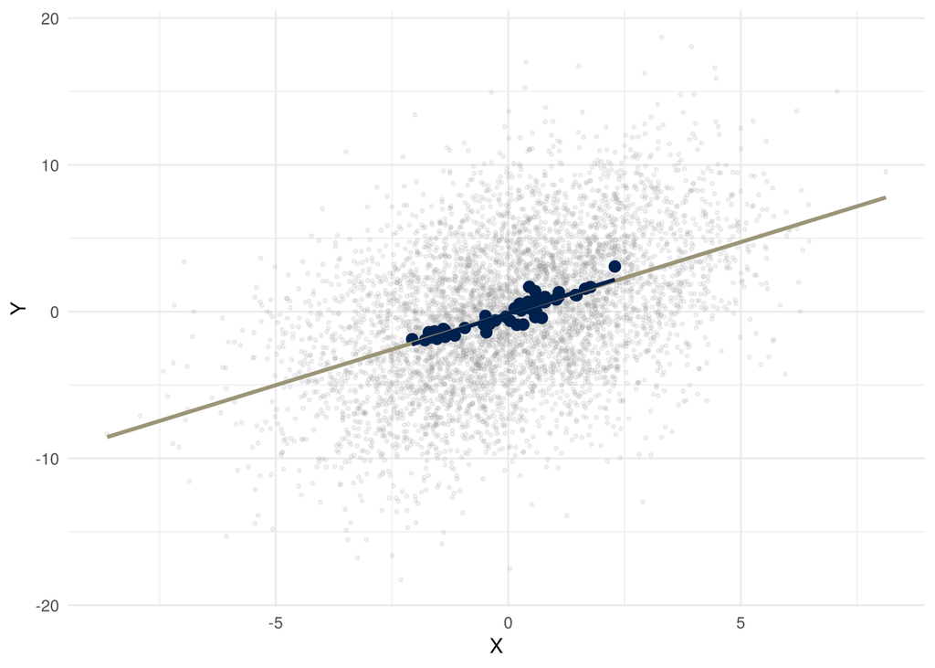

```r
ggplot(people, aes(X, Y)) +
  geom_point(alpha = 0.1, size = 0.7, color = "#7C7B78") +
  geom_point(data = areas, color = "#00204D", size = 2.5) +
  geom_smooth(method = "lm", se = FALSE, color = "#9B9477") +
  geom_smooth(data = areas, method = "lm", se = FALSE, color = "#00204D")
```

Slopes near 1 in both regressions. The formula from problem 4 gives an $R^2$ of 0.20 across people and, at $n = 100$, $1.04/(1.04 + 0.20) = 0.84$ across areas; with fifty areas the realized aggregate value moves by a few hundredths from run to run. The reader shown the area averages sees a tight relationship.

4. Add an area effect: `Y + rep(rnorm(J, 0, 1), each = n)`. Repeat 1 and 2. Compare with problem 6(a).
5. Make the within-area covariance positive and the between-area covariance negative: generate `Y` as `-0.5 * area_mean_x[area] + 0.5 * (X - area_mean_x[area]) + noise`. Check that the two slopes have opposite signs.

**NoteSolution**

```r
people_u <- people |> mutate(Y = Y + rep(rnorm(J, 0, 1), each = n))
areas_u <- people_u |> group_by(area) |> summarize(X = mean(X), Y = mean(Y))
c(people = summary(lm(Y ~ X, people_u))$r.squared, areas = summary(lm(Y ~ X, areas_u))$r.squared)
```

```
   people     areas
0.1795223 0.4088187
```

```r
people_flip <- people |>
  mutate(Y = -0.5 * area_mean_x[area] + 0.5 * (X - area_mean_x[area]) + rnorm(J * n, 0, 1.5))
areas_flip <- people_flip |> group_by(area) |> summarize(X = mean(X), Y = mean(Y))
c(people = coef(lm(Y ~ X, people_flip))[2], areas = coef(lm(Y ~ X, areas_flip))[2])
```

```
  people.X    areas.X
 0.2944148 -0.4640289
```

With the area effect the formula in problem 6(a) gives 0.19 across people and 0.46 across areas; with fifty areas the aggregate value varies by about 0.1 from run to run. In item 5 the slope across areas is negative and the slope across people positive.

#### B. The largest of $n$

1. Simulate the largest of $n$ standard normals, 2000 times, for $n = 1, 10, 100, 1000$. Compute the mean for each $n$ and compare with $2.51$ at $n = 100$ and with $\sqrt{2 \ln n}$.
2. Plot a histogram of the 2000 maxima at $n = 100$. Where is it relative to zero?
3. Check $E[M_n] = n/(n+1)$ for the uniform at $n = 4$ and the harmonic sum for the exponential at $n = 4$ by simulation.
4. A group has 1000 posts a day. Estimate by simulation the fraction of days on which its most extreme post exceeds 3, and compare with $1 - 0.99865^{1000}$.

**TipHint 1**

`replicate(2000, max(rnorm(100)))` gives 2000 maxima at $n = 100$.

**NoteSolution**

```r
ns <- c(1, 10, 100, 1000)
maxima <- sapply(ns, function(n) replicate(2000, max(rnorm(n))))
colnames(maxima) <- ns
rbind(simulated = colMeans(maxima), approx = sqrt(2 * log(ns)))
```

```
                    1       10      100     1000
simulated -0.04583626 1.529276 2.501274 3.241794
approx     0.00000000 2.145966 3.034854 3.716922
```

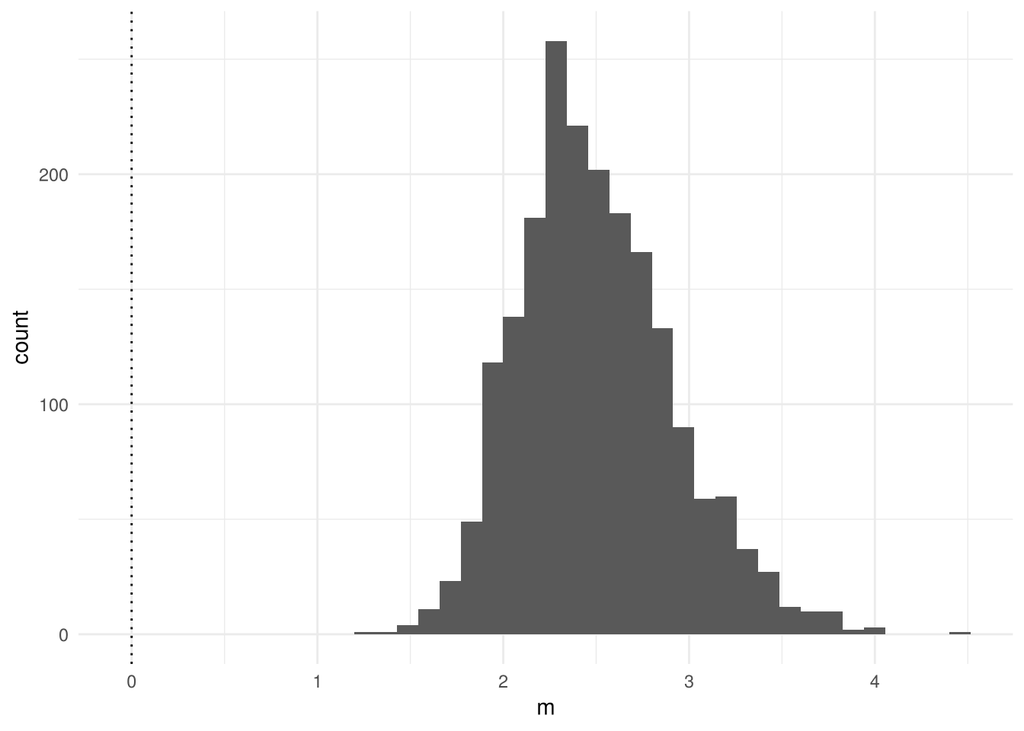

```r
data.frame(m = maxima[, "100"]) |>
  ggplot(aes(m)) + geom_histogram(bins = 40) +
  geom_vline(xintercept = 0, linetype = "dotted")
```

```r
c(uniform_4 = mean(replicate(5000, max(runif(4)))), formula = 4 / 5)
```

```
uniform_4   formula
0.7994002 0.8000000
```

```r
c(exponential_4 = mean(replicate(5000, max(rexp(4)))), formula = sum(1 / 1:4))
```

```
exponential_4       formula
     2.080043      2.083333
```

```r
c(simulated = mean(replicate(2000, max(rnorm(1000)) > 3)), formula = 1 - 0.99865^1000)
```

```
simulated   formula
0.7275000 0.7409961
```

The simulated means track the table in the notes (about 0, 1.5, 2.5, 3.2) and are below $\sqrt{2 \ln n}$ at every $n$ above 1. The histogram at $n = 100$ is centered near 2.5 with almost nothing below 1.5: every maximum looks extreme. The 1000-post group exceeds 3 on about three days in four.

#### C. Ecological regression on simulated precincts

Fifty precincts of equal size. The group’s share $x_i$ runs from 0.05 to 0.5. The group’s rate is $p = 0.3$ everywhere; everyone else’s rate is $q_i = 0.4 + 0.4\,x_i$.

1. Compute the precinct rates $y_i$ and fit `lm(y ~ x)`. Read off the two rates the regression reports and compare with the truth over all precincts.
2. Compute the Duncan–Davis bounds for $p_i$ and $q_i$ in each precinct and plot them against $x_i$. For which group and which precincts are they informative?
3. Set $q_i = 0.4$ (constancy holds) and repeat 1.

**NoteSolution**

```r
precincts <- data.frame(x = seq(0.05, 0.5, length.out = 50)) |>
  mutate(p = 0.3, q = 0.4 + 0.4 * x, y = p * x + q * (1 - x))
fit <- lm(y ~ x, precincts)
c(others = coef(fit)[1], group = sum(coef(fit)))
```

```
others.(Intercept)              group
         0.4232245          0.5032245
```

```r
with(precincts, c(others_truth = sum((1 - x) * q) / sum(1 - x), group_truth = 0.3))
```

```
others_truth  group_truth
   0.5003096    0.3000000
```

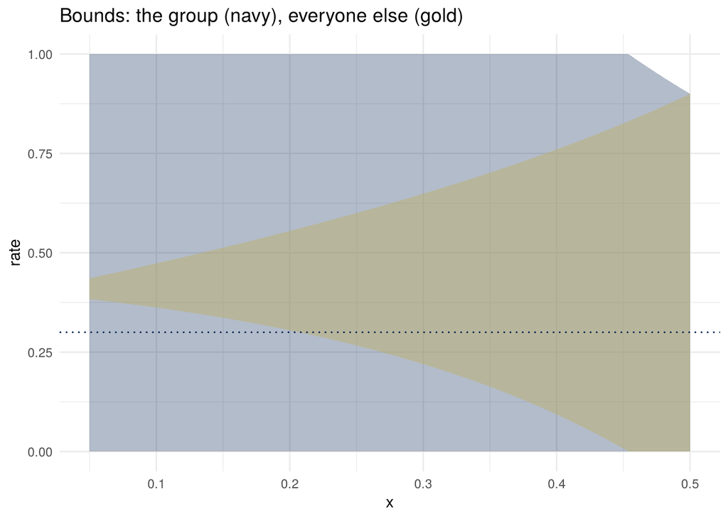

```r
precincts |>
  mutate(p_lo = pmax(0, (y - (1 - x)) / x), p_hi = pmin(1, y / x),
         q_lo = pmax(0, (y - x) / (1 - x)), q_hi = pmin(1, y / (1 - x))) |>
  ggplot(aes(x)) +
  geom_ribbon(aes(ymin = p_lo, ymax = p_hi), fill = "#00204D", alpha = 0.3) +
  geom_ribbon(aes(ymin = q_lo, ymax = q_hi), fill = "#BCAF6F", alpha = 0.5) +
  geom_hline(yintercept = 0.3, color = "#00204D", linetype = "dotted") +
  labs(y = "rate", title = "Bounds: the group (navy), everyone else (gold)")
```

```r
precincts_c <- precincts |> mutate(q = 0.4, y = p * x + q * (1 - x))
fit_c <- lm(y ~ x, precincts_c)
c(others = coef(fit_c)[1], group = sum(coef(fit_c)))
```

```
others.(Intercept)              group
               0.4                0.3
```

With the gradient in $q$, the regression reports the group’s rate at about 0.50 against a truth of 0.30, and everyone else’s at about 0.42 against 0.50 over all precincts: the gradient in $q$ has been moved to the wrong group. The shares here go up to 0.5, so the reported rate is well short of $p + \gamma = 0.7$. The bounds for the group are the whole of $[0, 1]$ in 44 of the 50 precincts (wherever $x \le y$, which is up to $x = 0.44$) and $[0, 0.9]$ at $x = 0.5$. The bounds for everyone else are narrow where $x$ is small, with width $x/(1 - x)$: $0.05$ at $x = 0.05$ and $0.5$ at $x = 1/3$. By $x = 0.5$ they are the same $[0, 0.9]$ as the group’s. With constancy the regression recovers 0.4 and 0.3 without error.